# Homework 2

### 16: Visualizazione FullBath

```r
visualization_discrete(na.omit(House_prices[,"FullBath"]), sum_info_h[16],"FullBath")
```

```
## [[1]]
## [[1]]$FullBath
## [[1]]$FullBath$Summary
##    Min. 1st Qu.  Median    Mean 3rd Qu.    Max.
##   0.000   1.000   2.000   1.565   2.000   3.000
##
## [[1]]$FullBath$Variance
## [1] 0.3
##
## [[1]]$FullBath$Standard_Deviation
## [1] 0.55
##
## [[1]]$FullBath$Moda
## [[1]]$FullBath$Moda$Mode
## [1] 2
##
## [[1]]$FullBath$Moda$Frequency
## [1] 768
##
##
##
##
## [1] "freq: "
##
## data
##   0   1   2   3
##   9 650 768  33
##
## [1] "percintile: "
##
## data
##          0          1          2          3
##  0.6164384 44.5205479 52.6027397  2.2602740
```

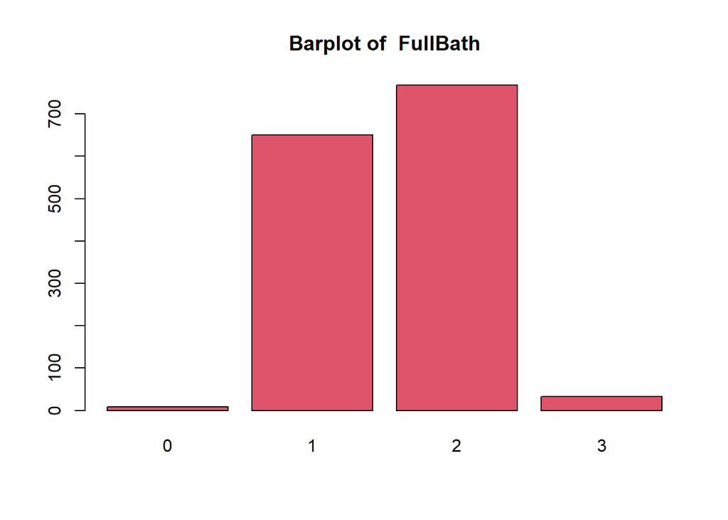

# Descrete Si osserva che la maggior parte degli edifici che sono sopra il seminterrato hanno 2 bagni completi essendo il ~=52.6% con frequenza di 768 Si osserva che la minima freq dei numeri di bagno completi e 9 per nessun bango e quindi si puo trascurare essendo <1% Si osserva che la freq dei numeri di bango completi per 3 bangi e 33 che è ~= 2.2% e quindi anch’esso trascurabile Infine si osserva che gli edifici che sono sopra il seminterrato che hanno 1 bagno completo sono il ~=44.5% con frequenza di 650

### 17: Visualizazione HalfBath

```r
visualization_discrete(na.omit(House_prices[,"HalfBath"]), sum_info_h[17],"HalfBath")
```

```
## [[1]]
## [[1]]$HalfBath
## [[1]]$HalfBath$Summary
##    Min. 1st Qu.  Median    Mean 3rd Qu.    Max.
##  0.0000  0.0000  0.0000  0.3829  1.0000  2.0000
##
## [[1]]$HalfBath$Variance
## [1] 0.25
##
## [[1]]$HalfBath$Standard_Deviation
## [1] 0.5
##
## [[1]]$HalfBath$Moda
## [[1]]$HalfBath$Moda$Mode
## [1] 0
##
## [[1]]$HalfBath$Moda$Frequency
## [1] 913
##
##
##
##
## [1] "freq: "
##
## data
##   0   1   2
## 913 535  12
##
## [1] "percintile: "
##
## data
##          0          1          2
## 62.5342466 36.6438356  0.8219178
```

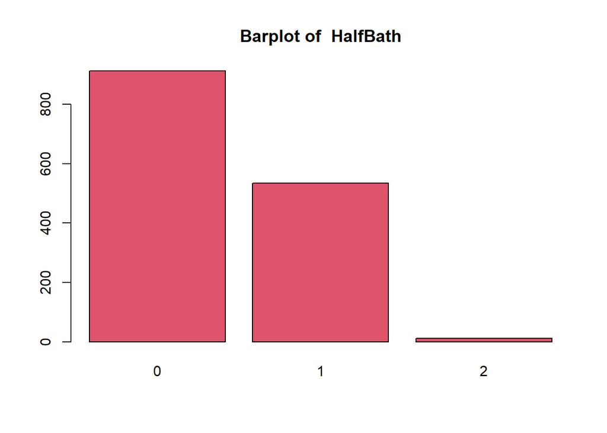

# Descrete Si osserva che la maggior parte degli edifici che sono sopra il seminterrato hanno 0 bagni mezzo completi essendo il ~=62.5% con frequenza di 913 Si osserva che la minima freq dei numeri di bagno completi e 12 per 2 bango e quindi si puo trascurare essendo <1% Infine si osserva che gli edifici che sono sopra il seminterrato che hanno 1 bagno completo sono il ~=36.6% con frequenza di 535

### 18: Visualizazione BedroomAbvGr

```r
visualization_discrete(na.omit(House_prices[,"BedroomAbvGr"]), sum_info_h[18],"BedroomAbvGr")
```

```
## [[1]]
## [[1]]$BedroomAbvGr
## [[1]]$BedroomAbvGr$Summary
##    Min. 1st Qu.  Median    Mean 3rd Qu.    Max.
##   0.000   2.000   3.000   2.866   3.000   8.000
##
## [[1]]$BedroomAbvGr$Variance
## [1] 0.67
##
## [[1]]$BedroomAbvGr$Standard_Deviation
## [1] 0.82
##
## [[1]]$BedroomAbvGr$Moda
## [[1]]$BedroomAbvGr$Moda$Mode
## [1] 3
##
## [[1]]$BedroomAbvGr$Moda$Frequency
## [1] 804
##
##
##
##
## [1] "freq: "
##
## data
##   0   1   2   3   4   5   6   8
##   6  50 358 804 213  21   7   1
##
## [1] "percintile: "
##
## data
##           0           1           2           3           4           5
##  0.41095890  3.42465753 24.52054795 55.06849315 14.58904110  1.43835616
##           6           8
##  0.47945205  0.06849315
```

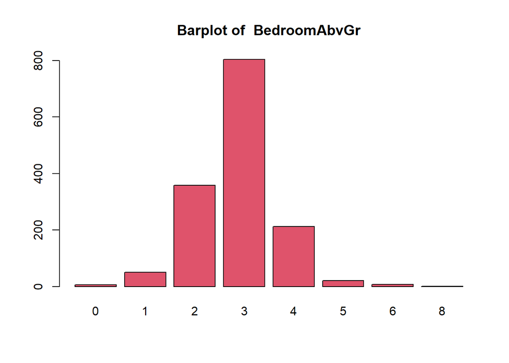

# Descrete Si osserva che la maggior parte degli edifici che sono sopra il seminterrato hanno 3 camere essendo il ~=55.07% con frequenza di 804 seguito da 2, 4 e 1 camere essendo ~=24.5%, ~=14.6% e ~=3.4% con frequenze 358, 213 e 50 rispettivamente. Si osserva che la minima freq dei numeri di camere e 1 per 8 camere seguito da 5, 6 e 0 camere con frequenze 21, 7 e 6 rispettivamente e quindi si puo trascurare essendo tutti <1.5%

### 19: Visualizazione KitchenAbvGr

```r
visualization_discrete(na.omit(House_prices[,"KitchenAbvGr"]), sum_info_h[19],"KitchenAbvGr")
```

```
## [[1]]
## [[1]]$KitchenAbvGr
## [[1]]$KitchenAbvGr$Summary
##    Min. 1st Qu.  Median    Mean 3rd Qu.    Max.
##   0.000   1.000   1.000   1.047   1.000   3.000
##
## [[1]]$KitchenAbvGr$Variance
## [1] 0.05
##
## [[1]]$KitchenAbvGr$Standard_Deviation
## [1] 0.22
##
## [[1]]$KitchenAbvGr$Moda
## [[1]]$KitchenAbvGr$Moda$Mode
## [1] 1
##
## [[1]]$KitchenAbvGr$Moda$Frequency
## [1] 1392
##
##
##
##
## [1] "freq: "
##
## data
##    0    1    2    3
##    1 1392   65    2
##
## [1] "percintile: "
##
## data
##           0           1           2           3
##  0.06849315 95.34246575  4.45205479  0.13698630
```

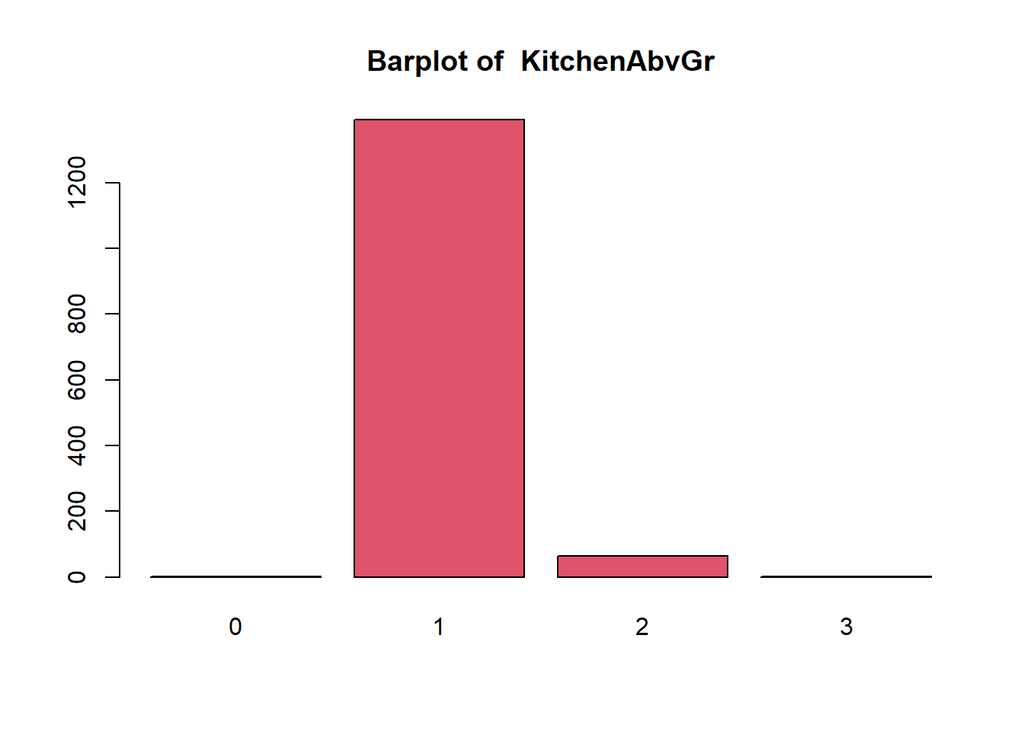

# Descrete Si osserva che la maggior parte degli edifici che sono sopra il seminterrato hanno 1 cucina essendo il ~=95.34% con frequenza di 1392 seguito da 2 cucine essendo ~=4.45% con frequenze 65. Si osserva che la minima freq dei numeri di camere e 1 per 0 cucine seguito da 3 cucine con frequenze 2 e quindi si puo trascurare essendo tutti <1%

### 20: Visualizazione TotRmsAbvGrd

```r
visualization_discrete(na.omit(House_prices[,"TotRmsAbvGrd"]), sum_info_h[20],"TotRmsAbvGrd")
```

```
## [[1]]
## [[1]]$TotRmsAbvGrd
## [[1]]$TotRmsAbvGrd$Summary
##    Min. 1st Qu.  Median    Mean 3rd Qu.    Max.
##   2.000   5.000   6.000   6.518   7.000  14.000
##
## [[1]]$TotRmsAbvGrd$Variance
## [1] 2.64
##
## [[1]]$TotRmsAbvGrd$Standard_Deviation
## [1] 1.63
##
## [[1]]$TotRmsAbvGrd$Moda
## [[1]]$TotRmsAbvGrd$Moda$Mode
## [1] 6
##
## [[1]]$TotRmsAbvGrd$Moda$Frequency
## [1] 402
##
##
##
##
## [1] "freq: "
##
## data
##   2   3   4   5   6   7   8   9  10  11  12  14
##   1  17  97 275 402 329 187  75  47  18  11   1
##
## [1] "percintile: "
##
## data
##           2           3           4           5           6           7
##  0.06849315  1.16438356  6.64383562 18.83561644 27.53424658 22.53424658
##           8           9          10          11          12          14
## 12.80821918  5.13698630  3.21917808  1.23287671  0.75342466  0.06849315
```

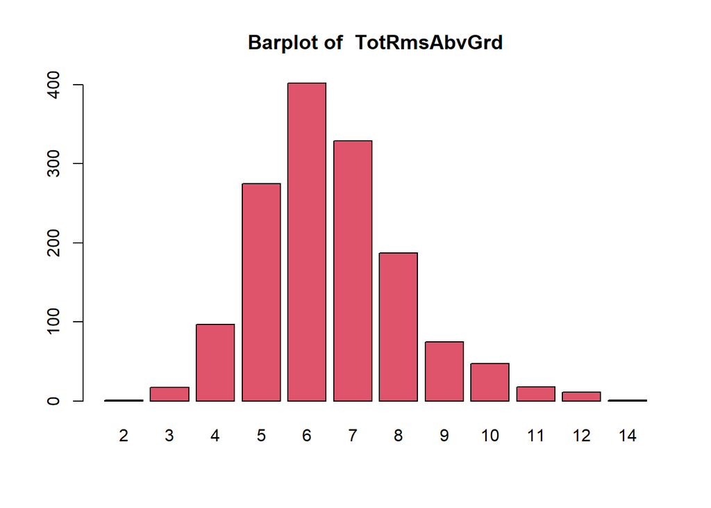

# Descrete Si osserva che la maggior parte degli edifici che sono sopra il seminterrato sono nel intervallo fra 5 e 7 stanze (non considerando i bagni) essendo il ~=68.8% con il piu grande di occorenze 6 stanze (~=27.5%) con frequenza di 402. Si osserva che la minima freq dei numeri di stanze e 1 per 2 e 14 stanze seguito da 12, 3 e 11 stanze con frequenze 11, 17 e 18 rispettivamente e quindi si puo trascurare essendo tutti <1.5%

### 21: Visualizazione Fireplaces

```r
visualization_discrete(na.omit(House_prices[,"Fireplaces"]), sum_info_h[21],"Fireplaces")
```

```
## [[1]]
## [[1]]$Fireplaces
## [[1]]$Fireplaces$Summary
##    Min. 1st Qu.  Median    Mean 3rd Qu.    Max.
##   0.000   0.000   1.000   0.613   1.000   3.000
##
## [[1]]$Fireplaces$Variance
## [1] 0.42
##
## [[1]]$Fireplaces$Standard_Deviation
## [1] 0.64
##
## [[1]]$Fireplaces$Moda
## [[1]]$Fireplaces$Moda$Mode
## [1] 0
##
## [[1]]$Fireplaces$Moda$Frequency
## [1] 690
##
##
##
##
## [1] "freq: "
##
## data
##   0   1   2   3
## 690 650 115   5
##
## [1] "percintile: "
##
## data
##          0          1          2          3
## 47.2602740 44.5205479  7.8767123  0.3424658
```

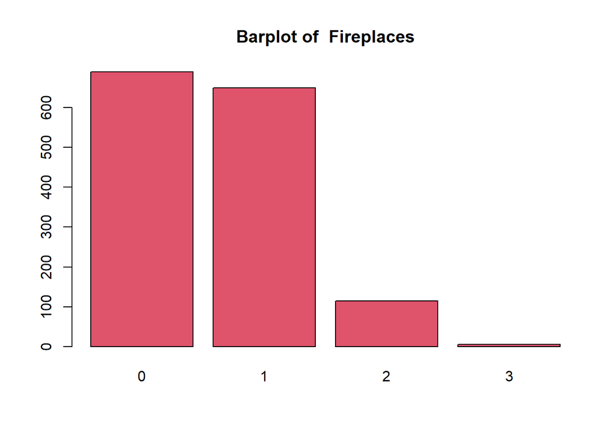

# Descrete Si osserva che la maggior parte degli edifici hanno 0 camini essendo il ~=47.26% con frequenza di 690 seguito da 1 e 2 camini essendo ~=44.52% con frequenze 650 e ~=7.88% con frequenza 115 rispettivamente. Si osserva che la minima freq dei numeri di camini e 5 per 3 camini e quindi si puo trascurare essendo <1%